# Riskified Test - Jagger Villalobos

Packages used for this analysis were the following;

```r
library(tidyverse)
```

# Summary

This challenge was a **great** exercise to implement the tidyverse package for its data-wrangling power and pipe functions for readability. Most of the syntax for tidyverse has similar function calls/verbs as SQL, so it is ideal for transforming data and sharing the results with other R & SQL users. I also harnessed the flexibility and power of the ggplot2 package for our data visualization questions.

# Reading the data

Setting column types to appropiate values which will be faster for larger data sets.

```r
test_data <- read_csv("/Users/jagvill/Desktop/Operations & Research Analyst - Test.csv", col_types= "ccd")
```

# Question 1

Draw a boxplot showing the area size distribution for each shape.

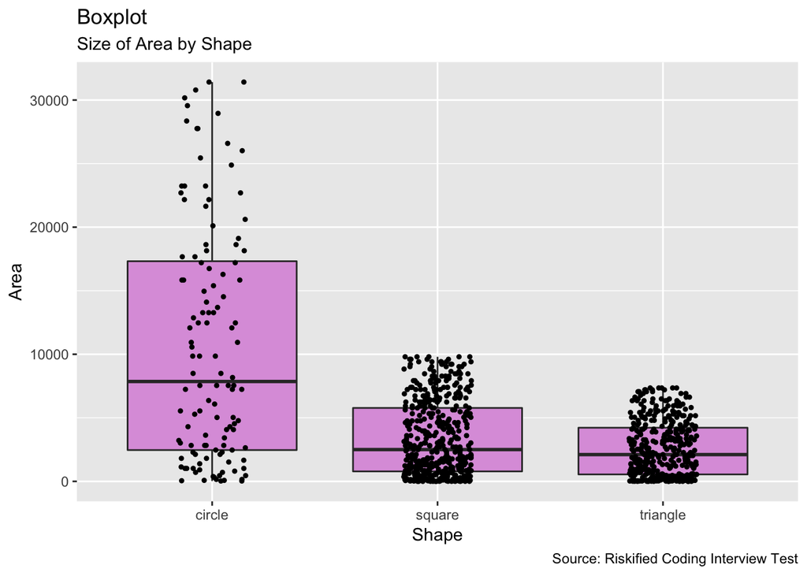

```r
ggplot(test_data, aes(shape,area)) +
  geom_boxplot(varwidth=F, fill="plum") +
  geom_jitter(shape=20, position=position_jitter(0.15)) +
  labs(
    title="Boxplot",
    subtitle="Size of Area by Shape",
    caption="Source: Riskified Coding Interview Test",
    x="Shape",
    y="Area"
  )
```

# Question 2

Calculate the mean, max, and standard deviation of the area size of each color.

```r
test_data %>% group_by(color) %>% summarize(Mean = mean(area), Max = max(area), St.Dev = sd(area))
```

| color | Mean | Max | St.Dev |
| --- | --- | --- | --- |
| blue | 3208.132 | 21642.4 | 3039.213 |
| green | 5761.119 | 27759.1 | 6695.030 |
| red | 3815.871 | 31415.9 | 5092.678 |
| yellow | 4538.208 | 31415.9 | 5352.461 |

# Question 3

What is the average area size of a yellow square?

```r
test_data %>%
  group_by(shape, color) %>%
  filter(color == "yellow" & shape == "square") %>%
  summarize(Avg.Area = mean(area))
```

| shape | color | Avg.Area |
| --- | --- | --- |
| square | yellow | 3333.207 |

# Question 4

Which shape is most likely to be green?

> The shape that is most likely to be green is a **square**, with **60.25%** probaility that a green shape is a square. I considered a simple approach of using the MODE, but decided to look at the probabilty outcomes.

```r
#Table containing the counts for shape and colors. Using MODE, if a green color shape was selected, then it will most likely be a square.
table(test_data$shape,test_data$color)
```

```
##
##            blue green red yellow
##   circle      9    31  30     50
##   square    152    47  56    222
##   triangle  199     0 204      0
```

```r
#Probability Approach
test_data %>%
  filter(color == "green") %>%
  group_by(shape) %>%
  summarize(counts = n()) %>%
  mutate(proportions = counts/sum(counts))
```

| shape | counts | proportions |
| --- | --- | --- |
| circle | 31 | 0.3974359 |
| square | 47 | 0.6025641 |

# Question 5

Given the fact the the object is red, with an area size larger than 3,000 - what are the chances the object is a square? a triangle? a circle?

> Using probabilty to find the chances, we can see that there is a **16.8%** chance that it will be a square, **16%** chance that it will be a circle, and a **67.2%** chance that it will be a triangle given the constraints stated in the question. We can implement classification models when we want to predict an outcome given certain data but was not necessary here.

```r
red3k_shapes <- test_data %>% filter(color == "red" & area > 3000)
prop.table(table(red3k_shapes$shape,red3k_shapes$color))
```

```
##
##              red
##   circle   0.160
##   square   0.168
##   triangle 0.672
```

# Question 6

Write a function that calculates the side or radius of an object, depending on the shape and area of the object [for an Equilateral triangle - area = (side ^ 2) * sqrt(3) / 4].

```r
# Applying a pseudo-open/closed principle, so if additonal shapes are added, no modification to our "side.radius.calc" function is needed. Less conditionals as well.

sides <- list(
            circle = function(area)sqrt(area/pi),
            triangle = function(area)sqrt(area/(sqrt(3)/4)),
            square = function(area)sqrt(area)
            )


side.radius.calc <- function(area, shape){
    sides[[shape]](area)
}
```

# Question 7

Add a column to the dataset called “side” that shows the size matching the area in each row, round that number to the closest integer (shape side or radios).

```r
test_side_data <- test_data %>%
                  mutate(side = map2(area, shape, side.radius.calc)) %>%
                  unnest() %>%
                  mutate(side = round(side))

# Print first 5 rows
head(test_side_data,5)
```

| shape | color | area | side |
| --- | --- | --- | --- |
| square | yellow | 9409.0 | 97 |
| circle | yellow | 4071.5 | 36 |
| triangle | blue | 2028.0 | 68 |
| square | blue | 3025.0 | 55 |
| square | blue | 9216.0 | 96 |

# Question 8

Draw a boxplot showing the side size distribution for each shape - what can you infer from this plot?

> Looking at the Boxplot results, we can see that the square & triangle shapes have greater density than the circle shapes, as there are greater observations. The variability in side lengths for circle & square are similar, but the variability is much greater for triangle shapes.

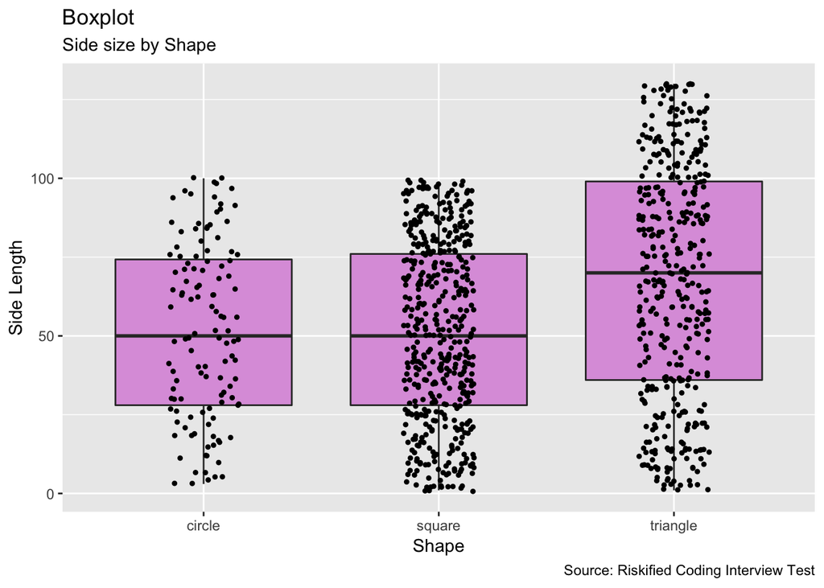

```r
ggplot(test_side_data, aes(shape,side)) +
  geom_boxplot(varwidth=F, fill="plum") +
  geom_jitter(shape=20,position=position_jitter(0.15)) +
  labs(
    title="Boxplot",
    subtitle="Side size by Shape",
    caption="Source: Riskified Coding Interview Test",
    x="Shape",
    y="Side Length"
  )
```

# Question 9

Make a scatter plot with “side” on the x axis, “area” on the y axis with a different color for each shape.

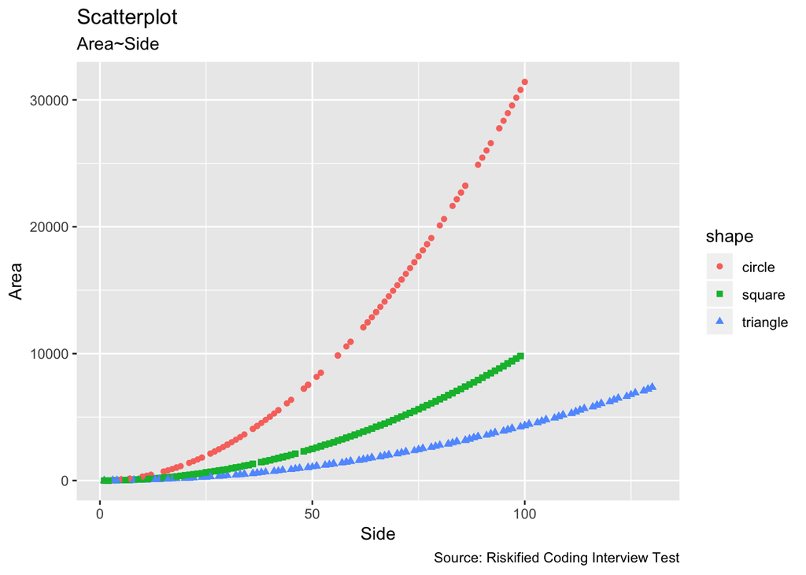

```r
ggplot(test_side_data, aes(side, area, shape = shape, color = shape)) +
  geom_point() +
  scale_shape_manual(values = c(16,15,17)) +
  labs(
    title="Scatterplot",
    subtitle="Area~Side",
    caption="Source: Riskified Coding Interview Test",
    x="Side",
    y="Area"
  )
```

# Question 10

A. The proportion of red objects within the shape.

B. The proporation of blue area out of the shapes total area (sum of square inch blue area of the shape, over sum of all shape size).

```r
#A.
test_data %>%
  group_by(shape) %>%
  mutate(shape_count = n()) %>%
  group_by(shape,color) %>%
  mutate(shape_total_colors = n()) %>%
  summarize(proportions = unique(shape_total_colors/shape_count)) %>%
  filter(color=="red")
```

| shape | color | proportions |
| --- | --- | --- |
| circle | red | 0.2500000 |
| square | red | 0.1174004 |
| triangle | red | 0.5062035 |

```r
#B.
test_data %>%
  group_by(shape) %>%
  mutate(total_shape_sqft = sum(area)) %>%
  group_by(shape,color) %>%
  mutate(total_shape_colors_sqft = sum(area)) %>%
  summarize(proportions = unique(total_shape_colors_sqft/total_shape_sqft))
```

| shape | color | proportions |
| --- | --- | --- |
| circle | blue | 0.06124595 |
| circle | green | 0.25318029 |
| circle | red | 0.30063626 |
| circle | yellow | 0.38493749 |
| square | blue | 0.36038508 |
| square | green | 0.07631438 |
| square | red | 0.10854602 |
| square | yellow | 0.45475452 |
| triangle | blue | 0.47388559 |
| triangle | red | 0.52611441 |

# Question 11

Create a function that calculates 10.B for any given shape and color

```r
proportions <- function(df, selection = NULL){

  #Get proportions for all shapes and colors, then we can filter for any aruements like color.
    res <- test_data %>%
      group_by(shape) %>%
      mutate(total_shape_sqft = sum(area)) %>%
      group_by(shape,color) %>%
      mutate(total_shape_colors_sqft = sum(area)) %>%
      summarize(proportions = unique(total_shape_colors_sqft/total_shape_sqft))

    #Check if "selection" is NULL, and if not then filter for color.
    if(!is.null(selection)) res <- res %>% ungroup() %>% filter(color == selection)
    return(res)
}
```

# Thank you

This was a ton of fun! I really appreciate the opporutnity and I look forward to discussing my results with the rest of the riskified team!